# Results: Midterm.sas

Gender by Parental Depression

The FREQ Procedure

| Frequency |
| --- |

| Table of gender by parent_label gender(Gender (1=Male, 2=Female)) | Table of gender by parent_label parent_label No Parental Depression | Table of gender by parent_label parent_label Parental Depression | Table of gender by parent_label parent_label Total |
| --- | --- | --- | --- |
| 1 | 42 | 63 | 105 |
| 2 | 53 | 62 | 115 |
| Total | 95 | 125 | 220 |

Child Depression by Parental Depression

The FREQ Procedure

| Frequency |
| --- |

| Table of depress_child by parent_label depress_child(Child Depression (0=No, 1=Yes)) | Table of depress_child by parent_label parent_label No Parental Depression | Table of depress_child by parent_label parent_label Parental Depression | Table of depress_child by parent_label parent_label Total |
| --- | --- | --- | --- |
| 0 | 73 | 78 | 151 |
| 1 | 22 | 47 | 69 |
| Total | 95 | 125 | 220 |

Substance Abuse by Parental Depression

The FREQ Procedure

| Frequency |
| --- |

| Table of substance_abuse by parent_label substance_abuse(Substance Abuse (0=No, 1=Yes)) | Table of substance_abuse by parent_label parent_label No Parental Depression | Table of substance_abuse by parent_label parent_label Parental Depression | Table of substance_abuse by parent_label parent_label Total |
| --- | --- | --- | --- |
| 0 | 88 | 104 | 192 |
| 1 | 7 | 21 | 28 |
| Total | 95 | 125 | 220 |

Social Class by Parental Depression

The FREQ Procedure

| Frequency |
| --- |

| Table of social_class by parent_label social_class(Social Class (1=Highest, 5=Lowest)) | Table of social_class by parent_label parent_label No Parental Depression | Table of social_class by parent_label parent_label Parental Depression | Table of social_class by parent_label parent_label Total |
| --- | --- | --- | --- |
| 1 | 1 | 16 | 17 |
| 2 | 19 | 19 | 38 |
| 3 | 16 | 31 | 47 |
| 4 | 47 | 50 | 97 |
| 5 | 12 | 8 | 20 |
| Total | 95 | 124 | 219 |
| Frequency Missing = 1 |  |  |  |

Marital Status by Parental Depression

The FREQ Procedure

| Frequency |
| --- |

| Table of marital_status by parent_label marital_status(Marital Status (1=Married, 2=Sep/Div)) | Table of marital_status by parent_label parent_label No Parental Depression | Table of marital_status by parent_label parent_label Parental Depression | Table of marital_status by parent_label parent_label Total |
| --- | --- | --- | --- |
| 1 | 84 | 90 | 174 |
| 2 | 11 | 35 | 46 |
| Total | 95 | 125 | 220 |

Summary Statistics

The MEANS Procedure

| Variable | Label | N | Mean | Std Dev |
| --- | --- | --- | --- | --- |
| time age | Time to Depression Onset or Censoring Age at Interview | 220 220 | 15.1909091 16.7227273 | 4.7378693 4.7388833 |

Censoring by Parental Depression Status

The FREQ Procedure

| Frequency |
| --- |

| Table of censor by parent_label censor(Censoring Status (1=Censored, 0=Event)) | Table of censor by parent_label parent_label No Parental Depression | Table of censor by parent_label parent_label Parental Depression | Table of censor by parent_label parent_label Total |
| --- | --- | --- | --- |
| 0 | 22 | 47 | 69 |
| 1 | 73 | 78 | 151 |
| Total | 95 | 125 | 220 |

Child Depression by Parental Depression

Overall Kaplan-Meier Survival Curves

The LIFETEST Procedure

Stratum 1: parent_label = No Parental Depression

| Product-Limit Survival Estimates time | Product-Limit Survival Estimates | Product-Limit Survival Estimates Survival | Product-Limit Survival Estimates Failure | Product-Limit Survival Estimates Survival Standard Error | Product-Limit Survival Estimates Number Failed | Product-Limit Survival Estimates Number Left |
| --- | --- | --- | --- | --- | --- | --- |
| 0.0000 |  | 1.0000 | 0 | 0 | 0 | 95 |
| 7.0000 | * | . | . | . | 0 | 94 |
| 8.0000 | * | . | . | . | 0 | 93 |
| 9.0000 | * | . | . | . | 0 | 92 |
| 9.0000 | * | . | . | . | 0 | 91 |
| 10.0000 | * | . | . | . | 0 | 90 |
| 10.0000 | * | . | . | . | 0 | 89 |
| 11.0000 | * | . | . | . | 0 | 88 |
| 11.0000 | * | . | . | . | 0 | 87 |
| 11.0000 | * | . | . | . | 0 | 86 |
| 11.0000 | * | . | . | . | 0 | 85 |
| 11.0000 | * | . | . | . | 0 | 84 |
| 12.0000 |  | . | . | . | 1 | 83 |
| 12.0000 |  | . | . | . | 2 | 82 |
| 12.0000 |  | 0.9643 | 0.0357 | 0.0202 | 3 | 81 |
| 12.0000 | * | . | . | . | 3 | 80 |
| 12.0000 | * | . | . | . | 3 | 79 |
| 12.0000 | * | . | . | . | 3 | 78 |
| 12.0000 | * | . | . | . | 3 | 77 |
| 12.0000 | * | . | . | . | 3 | 76 |
| 13.0000 |  | 0.9516 | 0.0484 | 0.0236 | 4 | 75 |
| 13.0000 | * | . | . | . | 4 | 74 |
| 13.0000 | * | . | . | . | 4 | 73 |
| 13.0000 | * | . | . | . | 4 | 72 |
| 13.0000 | * | . | . | . | 4 | 71 |
| 13.0000 | * | . | . | . | 4 | 70 |
| 13.0000 | * | . | . | . | 4 | 69 |
| 14.0000 |  | . | . | . | 5 | 68 |
| 14.0000 |  | 0.9240 | 0.0760 | 0.0299 | 6 | 67 |
| 14.0000 | * | . | . | . | 6 | 66 |

[output cut: 66 more lines]

Note:The marked survival times are censored observations.

Summary Statistics for Time Variable time

| Quartile Estimates Percent | Quartile Estimates Point Estimate | Quartile Estimates 95% Confidence Interval Transform | Quartile Estimates 95% Confidence Interval [Lower | Quartile Estimates 95% Confidence Interval Upper) |
| --- | --- | --- | --- | --- |
| 75 | . | LOGLOG | 23.0000 | . |
| 50 | 23.0000 | LOGLOG | 19.0000 | . |
| 25 | 18.0000 | LOGLOG | 17.0000 | 19.0000 |

| Mean | Standard Error |
| --- | --- |
| 20.6223 | 0.4352 |

Note:The mean survival time and its standard error were underestimated because the largest observation was censored and the estimation was restricted to the largest event time.

Child Depression by Parental Depression

Overall Kaplan-Meier Survival Curves

The LIFETEST Procedure

Stratum 2: parent_label = Parental Depression

| Product-Limit Survival Estimates time | Product-Limit Survival Estimates | Product-Limit Survival Estimates Survival | Product-Limit Survival Estimates Failure | Product-Limit Survival Estimates Survival Standard Error | Product-Limit Survival Estimates Number Failed | Product-Limit Survival Estimates Number Left |
| --- | --- | --- | --- | --- | --- | --- |
| 0.0000 |  | 1.0000 | 0 | 0 | 0 | 125 |
| 4.0000 |  | 0.9920 | 0.00800 | 0.00797 | 1 | 124 |
| 5.0000 |  | 0.9840 | 0.0160 | 0.0112 | 2 | 123 |
| 5.0000 | * | . | . | . | 2 | 122 |
| 6.0000 |  | 0.9759 | 0.0241 | 0.0137 | 3 | 121 |
| 6.0000 | * | . | . | . | 3 | 120 |
| 6.0000 | * | . | . | . | 3 | 119 |
| 7.0000 |  | . | . | . | 4 | 118 |
| 7.0000 |  | . | . | . | 5 | 117 |
| 7.0000 |  | . | . | . | 6 | 116 |
| 7.0000 |  | 0.9431 | 0.0569 | 0.0209 | 7 | 115 |
| 7.0000 | * | . | . | . | 7 | 114 |
| 7.0000 | * | . | . | . | 7 | 113 |
| 7.0000 | * | . | . | . | 7 | 112 |
| 7.0000 | * | . | . | . | 7 | 111 |
| 8.0000 |  | . | . | . | 8 | 110 |
| 8.0000 |  | 0.9261 | 0.0739 | 0.0237 | 9 | 109 |
| 8.0000 | * | . | . | . | 9 | 108 |
| 8.0000 | * | . | . | . | 9 | 107 |
| 8.0000 | * | . | . | . | 9 | 106 |
| 8.0000 | * | . | . | . | 9 | 105 |
| 9.0000 |  | 0.9173 | 0.0827 | 0.0251 | 10 | 104 |
| 9.0000 | * | . | . | . | 10 | 103 |
| 9.0000 | * | . | . | . | 10 | 102 |
| 9.0000 | * | . | . | . | 10 | 101 |
| 9.0000 | * | . | . | . | 10 | 100 |
| 9.0000 | * | . | . | . | 10 | 99 |
| 10.0000 |  | . | . | . | 11 | 98 |
| 10.0000 |  | . | . | . | 12 | 97 |
| 10.0000 |  | . | . | . | 13 | 96 |

[output cut: 96 more lines]

Note:The marked survival times are censored observations.

Summary Statistics for Time Variable time

| Quartile Estimates Percent | Quartile Estimates Point Estimate | Quartile Estimates 95% Confidence Interval Transform | Quartile Estimates 95% Confidence Interval [Lower | Quartile Estimates 95% Confidence Interval Upper) |
| --- | --- | --- | --- | --- |
| 75 | . | LOGLOG | . | . |
| 50 | 20.0000 | LOGLOG | 17.0000 | . |
| 25 | 13.0000 | LOGLOG | 12.0000 | 15.0000 |

| Mean | Standard Error |
| --- | --- |
| 17.1593 | 0.4669 |

Note:The mean survival time and its standard error were underestimated because the largest observation was censored and the estimation was restricted to the largest event time.

| Summary of the Number of Censored and Uncensored Values Stratum | Summary of the Number of Censored and Uncensored Values parent_label | Summary of the Number of Censored and Uncensored Values Total | Summary of the Number of Censored and Uncensored Values Failed | Summary of the Number of Censored and Uncensored Values Censored | Summary of the Number of Censored and Uncensored Values Percent Censored |
| --- | --- | --- | --- | --- | --- |
| 1 | No Parental Depression | 95 | 22 | 73 | 76.84 |
| 2 | Parental Depression | 125 | 47 | 78 | 62.40 |
| Total |  | 220 | 69 | 151 | 68.64 |

Child Depression by Parental Depression

Overall Kaplan-Meier Survival Curves

The LIFETEST Procedure

Testing Homogeneity of Survival Curves for time over Strata

| Rank Statistics parent_label | Rank Statistics Log-Rank | Rank Statistics Wilcoxon |
| --- | --- | --- |
| No Parental Depression | -11.262 | -2276.0 |
| Parental Depression | 11.262 | 2276.0 |

| Covariance Matrix for the Log-Rank Statistics parent_label | Covariance Matrix for the Log-Rank Statistics No Parental Depression | Covariance Matrix for the Log-Rank Statistics Parental Depression |
| --- | --- | --- |
| No Parental Depression | 16.4979 | -16.4979 |
| Parental Depression | -16.4979 | 16.4979 |

| Covariance Matrix for the Wilcoxon Statistics parent_label | Covariance Matrix for the Wilcoxon Statistics No Parental Depression | Covariance Matrix for the Wilcoxon Statistics Parental Depression |
| --- | --- | --- |
| No Parental Depression | 340944 | -340944 |
| Parental Depression | -340944 | 340944 |

| Test of Equality over Strata Test | Test of Equality over Strata Chi-Square | Test of Equality over Strata DF | Test of Equality over Strata Pr > Chi-Square |
| --- | --- | --- | --- |
| Log-Rank | 7.6876 | 1 | 0.0056 |
| Wilcoxon | 15.1936 | 1 | <.0001 |
| -2Log(LR) | 5.7178 | 1 | 0.0168 |

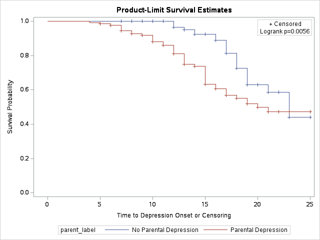

HYPOTHESIS 1a: Survival Curves for Pre-pubertal Depression Onset (<13 years)

Stratified by Parental Depression Status

The LIFETEST Procedure

Stratum 1: parent_label = No Parental Depression

| Product-Limit Survival Estimates time_prepub | Product-Limit Survival Estimates | Product-Limit Survival Estimates Survival | Product-Limit Survival Estimates Failure | Product-Limit Survival Estimates Survival Standard Error | Product-Limit Survival Estimates Number Failed | Product-Limit Survival Estimates Number Left |
| --- | --- | --- | --- | --- | --- | --- |
| 0.0000 |  | 1.0000 | 0 | 0 | 0 | 95 |
| 12.0000 |  | . | . | . | 1 | 94 |
| 12.0000 |  | . | . | . | 2 | 93 |
| 12.0000 |  | 0.9684 | 0.0316 | 0.0179 | 3 | 92 |
| 13.0000 | * | . | . | . | 3 | 91 |
| 13.0000 | * | . | . | . | 3 | 90 |
| 13.0000 | * | . | . | . | 3 | 89 |
| 13.0000 | * | . | . | . | 3 | 88 |
| 13.0000 | * | . | . | . | 3 | 87 |
| 13.0000 | * | . | . | . | 3 | 86 |
| 13.0000 | * | . | . | . | 3 | 85 |
| 13.0000 | * | . | . | . | 3 | 84 |
| 13.0000 | * | . | . | . | 3 | 83 |
| 13.0000 | * | . | . | . | 3 | 82 |
| 13.0000 | * | . | . | . | 3 | 81 |
| 13.0000 | * | . | . | . | 3 | 80 |
| 13.0000 | * | . | . | . | 3 | 79 |
| 13.0000 | * | . | . | . | 3 | 78 |
| 13.0000 | * | . | . | . | 3 | 77 |
| 13.0000 | * | . | . | . | 3 | 76 |
| 13.0000 | * | . | . | . | 3 | 75 |
| 13.0000 | * | . | . | . | 3 | 74 |
| 13.0000 | * | . | . | . | 3 | 73 |
| 13.0000 | * | . | . | . | 3 | 72 |
| 13.0000 | * | . | . | . | 3 | 71 |
| 13.0000 | * | . | . | . | 3 | 70 |
| 13.0000 | * | . | . | . | 3 | 69 |
| 13.0000 | * | . | . | . | 3 | 68 |
| 13.0000 | * | . | . | . | 3 | 67 |
| 13.0000 | * | . | . | . | 3 | 66 |

[output cut: 66 more lines]

Note:The marked survival times are censored observations.

Summary Statistics for Time Variable time_prepub

| Quartile Estimates Percent | Quartile Estimates Point Estimate | Quartile Estimates 95% Confidence Interval Transform | Quartile Estimates 95% Confidence Interval [Lower | Quartile Estimates 95% Confidence Interval Upper) |
| --- | --- | --- | --- | --- |
| 75 | . | LOGLOG | . | . |
| 50 | . | LOGLOG | . | . |
| 25 | . | LOGLOG | . | . |

| Mean | Standard Error |
| --- | --- |
| 12.0000 | 0.0000 |

Note:The mean survival time and its standard error were underestimated because the largest observation was censored and the estimation was restricted to the largest event time.

HYPOTHESIS 1a: Survival Curves for Pre-pubertal Depression Onset (<13 years)

Stratified by Parental Depression Status

The LIFETEST Procedure

Stratum 2: parent_label = Parental Depression

| Product-Limit Survival Estimates time_prepub | Product-Limit Survival Estimates | Product-Limit Survival Estimates Survival | Product-Limit Survival Estimates Failure | Product-Limit Survival Estimates Survival Standard Error | Product-Limit Survival Estimates Number Failed | Product-Limit Survival Estimates Number Left |
| --- | --- | --- | --- | --- | --- | --- |
| 0.0000 |  | 1.0000 | 0 | 0 | 0 | 125 |
| 4.0000 |  | 0.9920 | 0.00800 | 0.00797 | 1 | 124 |
| 5.0000 |  | 0.9840 | 0.0160 | 0.0112 | 2 | 123 |
| 6.0000 |  | 0.9760 | 0.0240 | 0.0137 | 3 | 122 |
| 7.0000 |  | . | . | . | 4 | 121 |
| 7.0000 |  | . | . | . | 5 | 120 |
| 7.0000 |  | . | . | . | 6 | 119 |
| 7.0000 |  | 0.9440 | 0.0560 | 0.0206 | 7 | 118 |
| 8.0000 |  | . | . | . | 8 | 117 |
| 8.0000 |  | 0.9280 | 0.0720 | 0.0231 | 9 | 116 |
| 9.0000 |  | 0.9200 | 0.0800 | 0.0243 | 10 | 115 |
| 10.0000 |  | . | . | . | 11 | 114 |
| 10.0000 |  | . | . | . | 12 | 113 |
| 10.0000 |  | . | . | . | 13 | 112 |
| 10.0000 |  | 0.8880 | 0.1120 | 0.0282 | 14 | 111 |
| 11.0000 |  | . | . | . | 15 | 110 |
| 11.0000 |  | 0.8720 | 0.1280 | 0.0299 | 16 | 109 |
| 12.0000 |  | . | . | . | 17 | 108 |
| 12.0000 |  | . | . | . | 18 | 107 |
| 12.0000 |  | . | . | . | 19 | 106 |
| 12.0000 |  | . | . | . | 20 | 105 |
| 12.0000 |  | 0.8320 | 0.1680 | 0.0334 | 21 | 104 |
| 13.0000 | * | . | . | . | 21 | 103 |
| 13.0000 | * | . | . | . | 21 | 102 |
| 13.0000 | * | . | . | . | 21 | 101 |
| 13.0000 | * | . | . | . | 21 | 100 |
| 13.0000 | * | . | . | . | 21 | 99 |
| 13.0000 | * | . | . | . | 21 | 98 |
| 13.0000 | * | . | . | . | 21 | 97 |
| 13.0000 | * | . | . | . | 21 | 96 |

[output cut: 96 more lines]

Note:The marked survival times are censored observations.

Summary Statistics for Time Variable time_prepub

| Quartile Estimates Percent | Quartile Estimates Point Estimate | Quartile Estimates 95% Confidence Interval Transform | Quartile Estimates 95% Confidence Interval [Lower | Quartile Estimates 95% Confidence Interval Upper) |
| --- | --- | --- | --- | --- |
| 75 | . | LOGLOG | . | . |
| 50 | . | LOGLOG | . | . |
| 25 | . | LOGLOG | . | . |

| Mean | Standard Error |
| --- | --- |
| 11.5040 | 0.1365 |

Note:The mean survival time and its standard error were underestimated because the largest observation was censored and the estimation was restricted to the largest event time.

| Summary of the Number of Censored and Uncensored Values Stratum | Summary of the Number of Censored and Uncensored Values parent_label | Summary of the Number of Censored and Uncensored Values Total | Summary of the Number of Censored and Uncensored Values Failed | Summary of the Number of Censored and Uncensored Values Censored | Summary of the Number of Censored and Uncensored Values Percent Censored |
| --- | --- | --- | --- | --- | --- |
| 1 | No Parental Depression | 95 | 3 | 92 | 96.84 |
| 2 | Parental Depression | 125 | 21 | 104 | 83.20 |
| Total |  | 220 | 24 | 196 | 89.09 |

HYPOTHESIS 1a: Survival Curves for Pre-pubertal Depression Onset (<13 years)

Stratified by Parental Depression Status

The LIFETEST Procedure

Testing Homogeneity of Survival Curves for time_prepub over Strata

| Rank Statistics parent_label | Rank Statistics Log-Rank | Rank Statistics Wilcoxon |
| --- | --- | --- |
| No Parental Depression | -7.8521 | -1668.0 |
| Parental Depression | 7.8521 | 1668.0 |

| Covariance Matrix for the Log-Rank Statistics parent_label | Covariance Matrix for the Log-Rank Statistics No Parental Depression | Covariance Matrix for the Log-Rank Statistics Parental Depression |
| --- | --- | --- |
| No Parental Depression | 5.84026 | -5.84026 |
| Parental Depression | -5.84026 | 5.84026 |

| Covariance Matrix for the Wilcoxon Statistics parent_label | Covariance Matrix for the Wilcoxon Statistics No Parental Depression | Covariance Matrix for the Wilcoxon Statistics Parental Depression |
| --- | --- | --- |
| No Parental Depression | 258434 | -258434 |
| Parental Depression | -258434 | 258434 |

| Test of Equality over Strata Test | Test of Equality over Strata Chi-Square | Test of Equality over Strata DF | Test of Equality over Strata Pr > Chi-Square |
| --- | --- | --- | --- |
| Log-Rank | 10.5571 | 1 | 0.0012 |
| Wilcoxon | 10.7657 | 1 | 0.0010 |
| -2Log(LR) | 11.4478 | 1 | 0.0007 |

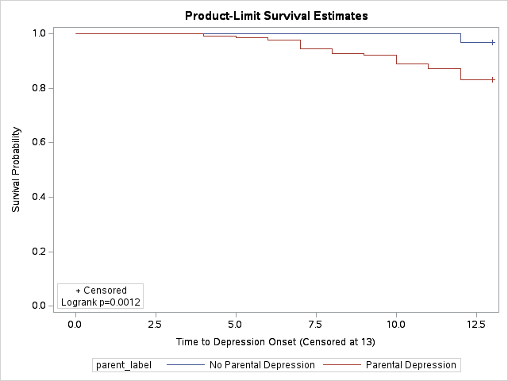

HYPOTHESIS 1a: Cox Regression for Pre-pubertal Depression Onset (<13 years)

Effect of Parental Depression controlling for demographics and social characteristics

The PHREG Procedure

| Model Information |  |  |
| --- | --- | --- |
| Data Set | WORK.PREPUBERTAL_DATA |  |
| Dependent Variable | time_prepub | Time to Depression Onset (Censored at 13) |
| Censoring Variable | censor_prepub | Censoring Status for Pre-pubertal Analysis |
| Censoring Value(s) | 1 |  |
| Ties Handling | BRESLOW |  |

| Number of Observations Read Number of Observations Used | 220 219 |
| --- | --- |

| Class Level Information Class | Class Level Information Value | Class Level Information Design Variables |
| --- | --- | --- |
| depress_parent | 0 | 0 |
|  | 1 | 1 |
| gender | 1 | 0 |
|  | 2 | 1 |
| marital_status | 1 | 0 |
|  | 2 | 1 |

| Summary of the Number of Event and Censored Values Total | Summary of the Number of Event and Censored Values Event | Summary of the Number of Event and Censored Values Censored | Summary of the Number of Event and Censored Values Percent Censored |
| --- | --- | --- | --- |
| 219 | 24 | 195 | 89.04 |

| Convergence Status |
| --- |
| Convergence criterion (GCONV=1E-8) satisfied. |

| Model Fit Statistics Criterion | Model Fit Statistics Without Covariates | Model Fit Statistics With Covariates |
| --- | --- | --- |
| -2 LOG L | 256.472 | 241.565 |
| AIC | 256.472 | 251.565 |
| SBC | 256.472 | 257.455 |

| Testing Global Null Hypothesis: BETA=0 Test | Testing Global Null Hypothesis: BETA=0 Chi-Square | Testing Global Null Hypothesis: BETA=0 DF | Testing Global Null Hypothesis: BETA=0 Pr > ChiSq |
| --- | --- | --- | --- |
| Likelihood Ratio | 14.9072 | 5 | 0.0108 |
| Score | 13.6814 | 5 | 0.0178 |
| Wald | 11.1151 | 5 | 0.0491 |

| Type 3 Tests Effect | Type 3 Tests DF | Type 3 Tests Wald Chi-Square | Type 3 Tests Pr > ChiSq |
| --- | --- | --- | --- |
| depress_parent | 1 | 7.9678 | 0.0048 |
| gender | 1 | 0.1459 | 0.7024 |
| age | 1 | 0.0926 | 0.7608 |
| social_class | 1 | 1.3461 | 0.2460 |
| marital_status | 1 | 0.9380 | 0.3328 |

| Analysis of Maximum Likelihood Estimates Parameter | Analysis of Maximum Likelihood Estimates | Analysis of Maximum Likelihood Estimates DF | Analysis of Maximum Likelihood Estimates Parameter Estimate | Analysis of Maximum Likelihood Estimates Standard Error | Analysis of Maximum Likelihood Estimates Chi-Square | Analysis of Maximum Likelihood Estimates Pr > ChiSq | Analysis of Maximum Likelihood Estimates Hazard Ratio | Analysis of Maximum Likelihood Estimates 95% Hazard Ratio Confidence Limits | Analysis of Maximum Likelihood Estimates 95% Hazard Ratio Confidence Limits | Analysis of Maximum Likelihood Estimates Label |
| --- | --- | --- | --- | --- | --- | --- | --- | --- | --- | --- |
| depress_parent | 1 | 1 | 1.76864 | 0.62657 | 7.9678 | 0.0048 | 5.863 | 1.717 | 20.019 | Parental Depression (0=No, 1=Yes) 1 |
| gender | 2 | 1 | 0.15749 | 0.41225 | 0.1459 | 0.7024 | 1.171 | 0.522 | 2.626 | Gender (1=Male, 2=Female) 2 |
| age |  | 1 | -0.01224 | 0.04023 | 0.0926 | 0.7608 | 0.988 | 0.913 | 1.069 | Age at Interview |
| social_class |  | 1 | -0.19553 | 0.16853 | 1.3461 | 0.2460 | 0.822 | 0.591 | 1.144 | Social Class (1=Highest, 5=Lowest) |
| marital_status | 2 | 1 | -0.53576 | 0.55318 | 0.9380 | 0.3328 | 0.585 | 0.198 | 1.731 | Marital Status (1=Married, 2=Sep/Div) 2 |

HYPOTHESIS 1a: Cox Regression with PH Assumption Test

The PHREG Procedure

| Model Information |  |  |
| --- | --- | --- |
| Data Set | WORK.PREPUBERTAL_DATA |  |
| Dependent Variable | time_prepub | Time to Depression Onset (Censored at 13) |
| Censoring Variable | censor_prepub | Censoring Status for Pre-pubertal Analysis |
| Censoring Value(s) | 1 |  |
| Ties Handling | EFRON |  |

| Number of Observations Read Number of Observations Used | 220 219 |
| --- | --- |

| Class Level Information Class | Class Level Information Value | Class Level Information Design Variables |
| --- | --- | --- |
| depress_parent | 0 | 0 |
|  | 1 | 1 |
| gender | 1 | 0 |
|  | 2 | 1 |
| marital_status | 1 | 0 |
|  | 2 | 1 |

| Summary of the Number of Event and Censored Values Total | Summary of the Number of Event and Censored Values Event | Summary of the Number of Event and Censored Values Censored | Summary of the Number of Event and Censored Values Percent Censored |
| --- | --- | --- | --- |
| 219 | 24 | 195 | 89.04 |

| Convergence Status |
| --- |
| Convergence criterion (GCONV=1E-8) satisfied. |

| Model Fit Statistics Criterion | Model Fit Statistics Without Covariates | Model Fit Statistics With Covariates |
| --- | --- | --- |
| -2 LOG L | 256.060 | 240.943 |
| AIC | 256.060 | 250.943 |
| SBC | 256.060 | 256.833 |

| Testing Global Null Hypothesis: BETA=0 Test | Testing Global Null Hypothesis: BETA=0 Chi-Square | Testing Global Null Hypothesis: BETA=0 DF | Testing Global Null Hypothesis: BETA=0 Pr > ChiSq |
| --- | --- | --- | --- |
| Likelihood Ratio | 15.1170 | 5 | 0.0099 |
| Score | 13.8965 | 5 | 0.0163 |
| Wald | 11.2807 | 5 | 0.0461 |

| Type 3 Tests Effect | Type 3 Tests DF | Type 3 Tests Wald Chi-Square | Type 3 Tests Pr > ChiSq |
| --- | --- | --- | --- |
| depress_parent | 1 | 8.0724 | 0.0045 |
| gender | 1 | 0.1594 | 0.6897 |
| age | 1 | 0.0872 | 0.7677 |
| social_class | 1 | 1.3748 | 0.2410 |
| marital_status | 1 | 0.9919 | 0.3193 |

| Analysis of Maximum Likelihood Estimates Parameter | Analysis of Maximum Likelihood Estimates | Analysis of Maximum Likelihood Estimates DF | Analysis of Maximum Likelihood Estimates Parameter Estimate | Analysis of Maximum Likelihood Estimates Standard Error | Analysis of Maximum Likelihood Estimates Chi-Square | Analysis of Maximum Likelihood Estimates Pr > ChiSq | Analysis of Maximum Likelihood Estimates Hazard Ratio | Analysis of Maximum Likelihood Estimates Label |
| --- | --- | --- | --- | --- | --- | --- | --- | --- |
| depress_parent | 1 | 1 | 1.78005 | 0.62651 | 8.0724 | 0.0045 | 5.930 | Parental Depression (0=No, 1=Yes) 1 |
| gender | 2 | 1 | 0.16457 | 0.41220 | 0.1594 | 0.6897 | 1.179 | Gender (1=Male, 2=Female) 2 |
| age |  | 1 | -0.01186 | 0.04014 | 0.0872 | 0.7677 | 0.988 | Age at Interview |
| social_class |  | 1 | -0.19683 | 0.16787 | 1.3748 | 0.2410 | 0.821 | Social Class (1=Highest, 5=Lowest) |
| marital_status | 2 | 1 | -0.55101 | 0.55327 | 0.9919 | 0.3193 | 0.576 | Marital Status (1=Married, 2=Sep/Div) 2 |

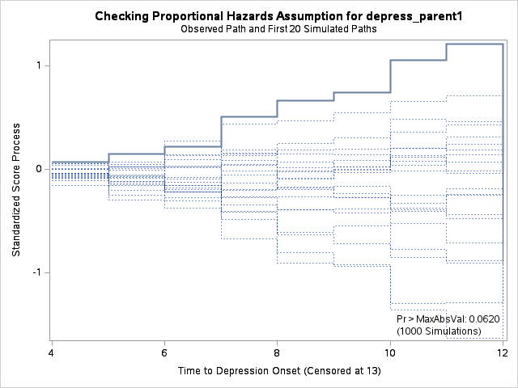

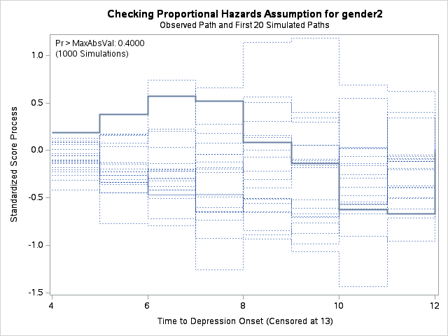

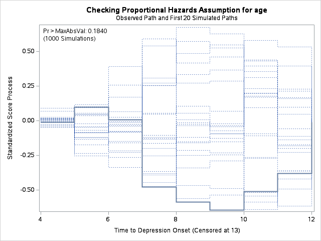

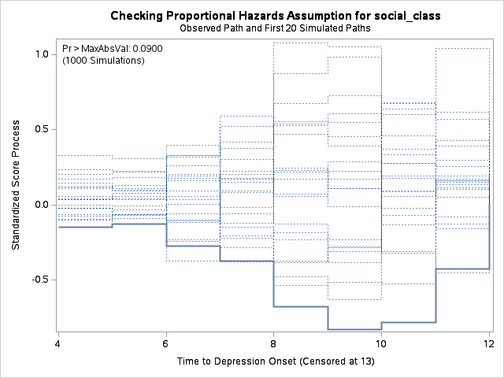

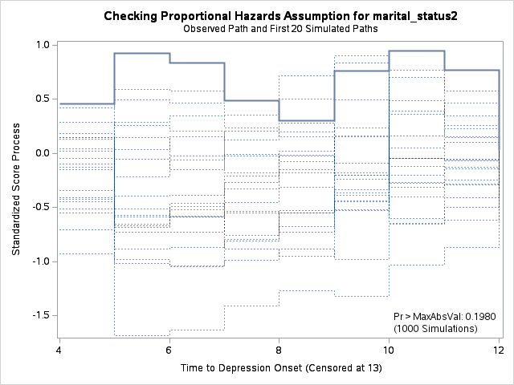

| Supremum Test for Proportionals Hazards Assumption Variable | Supremum Test for Proportionals Hazards Assumption Maximum Absolute Value | Supremum Test for Proportionals Hazards Assumption Replications | Supremum Test for Proportionals Hazards Assumption Seed | Supremum Test for Proportionals Hazards Assumption Pr > MaxAbsVal |
| --- | --- | --- | --- | --- |
| depress_parent1 | 1.2104 | 1000 | 1277129570 | 0.0620 |
| gender2 | 0.6671 | 1000 | 1277129570 | 0.4000 |
| age | 0.6435 | 1000 | 1277129570 | 0.1840 |
| social_class | 0.8294 | 1000 | 1277129570 | 0.0900 |
| marital_status2 | 0.9510 | 1000 | 1277129570 | 0.1980 |

Cox model with depress parent*time interaction

The PHREG Procedure

| Model Information |  |  |
| --- | --- | --- |
| Data Set | WORK.PREPUBERTAL_DATA |  |
| Dependent Variable | time_prepub | Time to Depression Onset (Censored at 13) |
| Censoring Variable | censor_prepub | Censoring Status for Pre-pubertal Analysis |
| Censoring Value(s) | 1 |  |
| Ties Handling | BRESLOW |  |

| Number of Observations Read Number of Observations Used | 220 219 |
| --- | --- |

| Class Level Information Class | Class Level Information Value | Class Level Information Design Variables |
| --- | --- | --- |
| depress_parent | 0 | 0 |
|  | 1 | 1 |
| gender | 1 | 0 |
|  | 2 | 1 |
| marital_status | 1 | 0 |
|  | 2 | 1 |

| Summary of the Number of Event and Censored Values Total | Summary of the Number of Event and Censored Values Event | Summary of the Number of Event and Censored Values Censored | Summary of the Number of Event and Censored Values Percent Censored |
| --- | --- | --- | --- |
| 219 | 24 | 195 | 89.04 |

| Convergence Status |
| --- |
| Convergence criterion (GCONV=1E-8) satisfied. |

| Model Fit Statistics Criterion | Model Fit Statistics Without Covariates | Model Fit Statistics With Covariates |
| --- | --- | --- |
| -2 LOG L | 256.472 | 234.407 |
| AIC | 256.472 | 246.407 |
| SBC | 256.472 | 253.475 |

| Testing Global Null Hypothesis: BETA=0 Test | Testing Global Null Hypothesis: BETA=0 Chi-Square | Testing Global Null Hypothesis: BETA=0 DF | Testing Global Null Hypothesis: BETA=0 Pr > ChiSq |
| --- | --- | --- | --- |
| Likelihood Ratio | 22.0647 | 6 | 0.0012 |
| Score | 14.7470 | 6 | 0.0223 |
| Wald | 3.0358 | 6 | 0.8043 |

| Type 3 Tests Effect | Type 3 Tests DF | Type 3 Tests Wald Chi-Square | Type 3 Tests Pr > ChiSq |
| --- | --- | --- | --- |
| depress_parent | 1 | 0.0002 | 0.9891 |
| gender | 1 | 0.1550 | 0.6938 |
| age | 1 | 0.0928 | 0.7606 |
| social_class | 1 | 1.3361 | 0.2477 |
| marital_status | 1 | 0.9266 | 0.3358 |
| depress_parent_time | 1 | 0.0002 | 0.9891 |

| Analysis of Maximum Likelihood Estimates Parameter | Analysis of Maximum Likelihood Estimates | Analysis of Maximum Likelihood Estimates DF | Analysis of Maximum Likelihood Estimates Parameter Estimate | Analysis of Maximum Likelihood Estimates Standard Error | Analysis of Maximum Likelihood Estimates Chi-Square | Analysis of Maximum Likelihood Estimates Pr > ChiSq | Analysis of Maximum Likelihood Estimates Hazard Ratio | Analysis of Maximum Likelihood Estimates Label |
| --- | --- | --- | --- | --- | --- | --- | --- | --- |
| depress_parent | 1 | 1 | 401.25918 | 29368 | 0.0002 | 0.9891 | 1.84E174 | Parental Depression (0=No, 1=Yes) 1 |
| gender | 2 | 1 | 0.16232 | 0.41225 | 0.1550 | 0.6938 | 1.176 | Gender (1=Male, 2=Female) 2 |
| age |  | 1 | -0.01228 | 0.04030 | 0.0928 | 0.7606 | 0.988 | Age at Interview |
| social_class |  | 1 | -0.19495 | 0.16865 | 1.3361 | 0.2477 | 0.823 | Social Class (1=Highest, 5=Lowest) |
| marital_status | 2 | 1 | -0.53243 | 0.55312 | 0.9266 | 0.3358 | 0.587 | Marital Status (1=Married, 2=Sep/Div) 2 |
| depress_parent_time |  | 1 | -161.32121 | 11819 | 0.0002 | 0.9891 | 0.000 |  |

HYPOTHESIS 1a: Stratified Cox Model

The PHREG Procedure

| Model Information |  |  |
| --- | --- | --- |
| Data Set | WORK.PREPUBERTAL_DATA |  |
| Dependent Variable | time_prepub | Time to Depression Onset (Censored at 13) |
| Censoring Variable | censor_prepub | Censoring Status for Pre-pubertal Analysis |
| Censoring Value(s) | 1 |  |
| Ties Handling | EFRON |  |

| Number of Observations Read Number of Observations Used | 220 219 |
| --- | --- |

| Class Level Information Class | Class Level Information Value | Class Level Information Design Variables |
| --- | --- | --- |
| gender | 1 | 0 |
|  | 2 | 1 |
| marital_status | 1 | 0 |
|  | 2 | 1 |

| Summary of the Number of Event and Censored Values Stratum | Summary of the Number of Event and Censored Values depress_parent | Summary of the Number of Event and Censored Values Total | Summary of the Number of Event and Censored Values Event | Summary of the Number of Event and Censored Values Censored | Summary of the Number of Event and Censored Values Percent Censored |
| --- | --- | --- | --- | --- | --- |
| 1 | 0 | 95 | 3 | 92 | 96.84 |
| 2 | 1 | 124 | 21 | 103 | 83.06 |
| Total |  | 219 | 24 | 195 | 89.04 |

| Convergence Status |
| --- |
| Convergence criterion (GCONV=1E-8) satisfied. |

| Model Fit Statistics Criterion | Model Fit Statistics Without Covariates | Model Fit Statistics With Covariates |
| --- | --- | --- |
| -2 LOG L | 226.120 | 223.255 |
| AIC | 226.120 | 231.255 |
| SBC | 226.120 | 235.967 |

| Testing Global Null Hypothesis: BETA=0 Test | Testing Global Null Hypothesis: BETA=0 Chi-Square | Testing Global Null Hypothesis: BETA=0 DF | Testing Global Null Hypothesis: BETA=0 Pr > ChiSq |
| --- | --- | --- | --- |
| Likelihood Ratio | 2.8654 | 4 | 0.5806 |
| Score | 2.8634 | 4 | 0.5809 |
| Wald | 2.7952 | 4 | 0.5927 |

| Type 3 Tests Effect | Type 3 Tests DF | Type 3 Tests Wald Chi-Square | Type 3 Tests Pr > ChiSq |
| --- | --- | --- | --- |
| gender | 1 | 0.1622 | 0.6871 |
| age | 1 | 0.0907 | 0.7633 |
| social_class | 1 | 1.3547 | 0.2445 |
| marital_status | 1 | 0.9710 | 0.3244 |

| Analysis of Maximum Likelihood Estimates Parameter | Analysis of Maximum Likelihood Estimates | Analysis of Maximum Likelihood Estimates DF | Analysis of Maximum Likelihood Estimates Parameter Estimate | Analysis of Maximum Likelihood Estimates Standard Error | Analysis of Maximum Likelihood Estimates Chi-Square | Analysis of Maximum Likelihood Estimates Pr > ChiSq | Analysis of Maximum Likelihood Estimates Hazard Ratio | Analysis of Maximum Likelihood Estimates 95% Hazard Ratio Confidence Limits | Analysis of Maximum Likelihood Estimates 95% Hazard Ratio Confidence Limits | Analysis of Maximum Likelihood Estimates Label |
| --- | --- | --- | --- | --- | --- | --- | --- | --- | --- | --- |
| gender | 2 | 1 | 0.16603 | 0.41219 | 0.1622 | 0.6871 | 1.181 | 0.526 | 2.648 | Gender (1=Male, 2=Female) 2 |
| age |  | 1 | -0.01211 | 0.04021 | 0.0907 | 0.7633 | 0.988 | 0.913 | 1.069 | Age at Interview |
| social_class |  | 1 | -0.19568 | 0.16813 | 1.3547 | 0.2445 | 0.822 | 0.591 | 1.143 | Social Class (1=Highest, 5=Lowest) |
| marital_status | 2 | 1 | -0.54506 | 0.55315 | 0.9710 | 0.3244 | 0.580 | 0.196 | 1.714 | Marital Status (1=Married, 2=Sep/Div) 2 |

HYPOTHESIS 1b: Survival Curves for Adolescent/Early Adulthood Depression Onset (>=13 years)

Stratified by Parental Depression Status - Time since age 13

The LIFETEST Procedure

Stratum 1: parent_label = No Parental Depression

| Product-Limit Survival Estimates time_since_13 | Product-Limit Survival Estimates | Product-Limit Survival Estimates Survival | Product-Limit Survival Estimates Failure | Product-Limit Survival Estimates Survival Standard Error | Product-Limit Survival Estimates Number Failed | Product-Limit Survival Estimates Number Left |
| --- | --- | --- | --- | --- | --- | --- |
| 0.0000 |  | 1.0000 | 0 | 0 | 0 | 76 |
| 0.0000 |  | 0.9868 | 0.0132 | 0.0131 | 1 | 75 |
| 0.0000 | * | . | . | . | 1 | 74 |
| 0.0000 | * | . | . | . | 1 | 73 |
| 0.0000 | * | . | . | . | 1 | 72 |
| 0.0000 | * | . | . | . | 1 | 71 |
| 0.0000 | * | . | . | . | 1 | 70 |
| 0.0000 | * | . | . | . | 1 | 69 |
| 1.0000 |  | . | . | . | 2 | 68 |
| 1.0000 |  | 0.9582 | 0.0418 | 0.0236 | 3 | 67 |
| 1.0000 | * | . | . | . | 3 | 66 |
| 1.0000 | * | . | . | . | 3 | 65 |
| 1.0000 | * | . | . | . | 3 | 64 |
| 1.0000 | * | . | . | . | 3 | 63 |
| 1.0000 | * | . | . | . | 3 | 62 |
| 1.0000 | * | . | . | . | 3 | 61 |
| 1.0000 | * | . | . | . | 3 | 60 |
| 1.0000 | * | . | . | . | 3 | 59 |
| 2.0000 | * | . | . | . | 3 | 58 |
| 2.0000 | * | . | . | . | 3 | 57 |
| 2.0000 | * | . | . | . | 3 | 56 |
| 2.0000 | * | . | . | . | 3 | 55 |
| 3.0000 |  | . | . | . | 4 | 54 |
| 3.0000 |  | 0.9234 | 0.0766 | 0.0332 | 5 | 53 |
| 3.0000 | * | . | . | . | 5 | 52 |
| 3.0000 | * | . | . | . | 5 | 51 |
| 3.0000 | * | . | . | . | 5 | 50 |
| 3.0000 | * | . | . | . | 5 | 49 |
| 3.0000 | * | . | . | . | 5 | 48 |
| 3.0000 | * | . | . | . | 5 | 47 |
| 3.0000 | * | . | . | . | 5 | 46 |
| 4.0000 |  | . | . | . | 6 | 45 |
| 4.0000 |  | . | . | . | 7 | 44 |
| 4.0000 |  | . | . | . | 8 | 43 |
| 4.0000 |  | 0.8431 | 0.1569 | 0.0489 | 9 | 42 |
| 4.0000 | * | . | . | . | 9 | 41 |
| 4.0000 | * | . | . | . | 9 | 40 |
| 4.0000 | * | . | . | . | 9 | 39 |
| 4.0000 | * | . | . | . | 9 | 38 |
| 4.0000 | * | . | . | . | 9 | 37 |
| 5.0000 |  | . | . | . | 10 | 36 |
| 5.0000 |  | . | . | . | 11 | 35 |
| 5.0000 |  | . | . | . | 12 | 34 |
| 5.0000 |  | 0.7520 | 0.2480 | 0.0613 | 13 | 33 |
| 5.0000 | * | . | . | . | 13 | 32 |
| 5.0000 | * | . | . | . | 13 | 31 |
| 5.0000 | * | . | . | . | 13 | 30 |
| 6.0000 |  | . | . | . | 14 | 29 |
| 6.0000 |  | . | . | . | 15 | 28 |
| 6.0000 |  | . | . | . | 16 | 27 |
| 6.0000 |  | 0.6517 | 0.3483 | 0.0707 | 17 | 26 |
| 6.0000 | * | . | . | . | 17 | 25 |
| 6.0000 | * | . | . | . | 17 | 24 |
| 6.0000 | * | . | . | . | 17 | 23 |
| 6.0000 | * | . | . | . | 17 | 22 |
| 6.0000 | * | . | . | . | 17 | 21 |
| 7.0000 | * | . | . | . | 17 | 20 |
| 7.0000 | * | . | . | . | 17 | 19 |
| 7.0000 | * | . | . | . | 17 | 18 |
| 7.0000 | * | . | . | . | 17 | 17 |
| 7.0000 | * | . | . | . | 17 | 16 |
| 7.0000 | * | . | . | . | 17 | 15 |
| 8.0000 |  | 0.6082 | 0.3918 | 0.0782 | 18 | 14 |
| 8.0000 | * | . | . | . | 18 | 13 |
| 8.0000 | * | . | . | . | 18 | 12 |
| 8.0000 | * | . | . | . | 18 | 11 |
| 8.0000 | * | . | . | . | 18 | 10 |
| 8.0000 | * | . | . | . | 18 | 9 |
| 8.0000 | * | . | . | . | 18 | 8 |
| 9.0000 | * | . | . | . | 18 | 7 |
| 9.0000 | * | . | . | . | 18 | 6 |
| 9.0000 | * | . | . | . | 18 | 5 |
| 9.0000 | * | . | . | . | 18 | 4 |
| 10.0000 |  | 0.4562 | 0.5438 | 0.1442 | 19 | 3 |
| 10.0000 | * | . | . | . | 19 | 2 |
| 10.0000 | * | . | . | . | 19 | 1 |
| 12.0000 | * | . | . | . | 19 | 0 |

Note:The marked survival times are censored observations.

Summary Statistics for Time Variable time_since_13

| Quartile Estimates Percent | Quartile Estimates Point Estimate | Quartile Estimates 95% Confidence Interval Transform | Quartile Estimates 95% Confidence Interval [Lower | Quartile Estimates 95% Confidence Interval Upper) |
| --- | --- | --- | --- | --- |
| 75 | . | LOGLOG | 10.0000 | . |
| 50 | 10.0000 | LOGLOG | 6.0000 | . |
| 25 | 6.0000 | LOGLOG | 4.0000 | 8.0000 |

| Mean | Standard Error |
| --- | --- |
| 7.9416 | 0.4099 |

Note:The mean survival time and its standard error were underestimated because the largest observation was censored and the estimation was restricted to the largest event time.

HYPOTHESIS 1b: Survival Curves for Adolescent/Early Adulthood Depression Onset (>=13 years)

Stratified by Parental Depression Status - Time since age 13

The LIFETEST Procedure

Stratum 2: parent_label = Parental Depression

| Product-Limit Survival Estimates time_since_13 | Product-Limit Survival Estimates | Product-Limit Survival Estimates Survival | Product-Limit Survival Estimates Failure | Product-Limit Survival Estimates Survival Standard Error | Product-Limit Survival Estimates Number Failed | Product-Limit Survival Estimates Number Left |
| --- | --- | --- | --- | --- | --- | --- |
| 0.0000 |  | 1.0000 | 0 | 0 | 0 | 78 |
| 0.0000 |  | . | . | . | 1 | 77 |
| 0.0000 |  | . | . | . | 2 | 76 |
| 0.0000 |  | . | . | . | 3 | 75 |
| 0.0000 |  | . | . | . | 4 | 74 |
| 0.0000 |  | . | . | . | 5 | 73 |
| 0.0000 |  | 0.9231 | 0.0769 | 0.0302 | 6 | 72 |
| 0.0000 | * | . | . | . | 6 | 71 |
| 0.0000 | * | . | . | . | 6 | 70 |
| 0.0000 | * | . | . | . | 6 | 69 |
| 0.0000 | * | . | . | . | 6 | 68 |
| 1.0000 |  | 0.9095 | 0.0905 | 0.0326 | 7 | 67 |
| 1.0000 | * | . | . | . | 7 | 66 |
| 1.0000 | * | . | . | . | 7 | 65 |
| 1.0000 | * | . | . | . | 7 | 64 |
| 1.0000 | * | . | . | . | 7 | 63 |
| 2.0000 |  | . | . | . | 8 | 62 |
| 2.0000 |  | . | . | . | 9 | 61 |
| 2.0000 |  | . | . | . | 10 | 60 |
| 2.0000 |  | . | . | . | 11 | 59 |
| 2.0000 |  | . | . | . | 12 | 58 |
| 2.0000 |  | . | . | . | 13 | 57 |
| 2.0000 |  | . | . | . | 14 | 56 |
| 2.0000 |  | . | . | . | 15 | 55 |
| 2.0000 |  | 0.7796 | 0.2204 | 0.0489 | 16 | 54 |
| 2.0000 | * | . | . | . | 16 | 53 |
| 2.0000 | * | . | . | . | 16 | 52 |
| 2.0000 | * | . | . | . | 16 | 51 |
| 3.0000 |  | . | . | . | 17 | 50 |
| 3.0000 |  | 0.7490 | 0.2510 | 0.0515 | 18 | 49 |
| 3.0000 | * | . | . | . | 18 | 48 |
| 3.0000 | * | . | . | . | 18 | 47 |
| 3.0000 | * | . | . | . | 18 | 46 |
| 3.0000 | * | . | . | . | 18 | 45 |
| 4.0000 |  | . | . | . | 19 | 44 |
| 4.0000 |  | . | . | . | 20 | 43 |
| 4.0000 |  | 0.6991 | 0.3009 | 0.0556 | 21 | 42 |
| 4.0000 | * | . | . | . | 21 | 41 |
| 4.0000 | * | . | . | . | 21 | 40 |
| 4.0000 | * | . | . | . | 21 | 39 |
| 4.0000 | * | . | . | . | 21 | 38 |
| 5.0000 |  | 0.6807 | 0.3193 | 0.0571 | 22 | 37 |
| 5.0000 | * | . | . | . | 22 | 36 |
| 5.0000 | * | . | . | . | 22 | 35 |
| 5.0000 | * | . | . | . | 22 | 34 |
| 6.0000 |  | . | . | . | 23 | 33 |
| 6.0000 |  | 0.6406 | 0.3594 | 0.0603 | 24 | 32 |
| 6.0000 | * | . | . | . | 24 | 31 |
| 6.0000 | * | . | . | . | 24 | 30 |
| 6.0000 | * | . | . | . | 24 | 29 |
| 6.0000 | * | . | . | . | 24 | 28 |
| 6.0000 | * | . | . | . | 24 | 27 |
| 6.0000 | * | . | . | . | 24 | 26 |
| 7.0000 |  | 0.6160 | 0.3840 | 0.0628 | 25 | 25 |
| 7.0000 | * | . | . | . | 25 | 24 |
| 7.0000 | * | . | . | . | 25 | 23 |
| 7.0000 | * | . | . | . | 25 | 22 |
| 7.0000 | * | . | . | . | 25 | 21 |
| 7.0000 | * | . | . | . | 25 | 20 |
| 7.0000 | * | . | . | . | 25 | 19 |
| 7.0000 | * | . | . | . | 25 | 18 |
| 8.0000 |  | 0.5818 | 0.4182 | 0.0680 | 26 | 17 |
| 8.0000 | * | . | . | . | 26 | 16 |
| 8.0000 | * | . | . | . | 26 | 15 |
| 8.0000 | * | . | . | . | 26 | 14 |
| 9.0000 | * | . | . | . | 26 | 13 |
| 9.0000 | * | . | . | . | 26 | 12 |
| 9.0000 | * | . | . | . | 26 | 11 |
| 9.0000 | * | . | . | . | 26 | 10 |
| 9.0000 | * | . | . | . | 26 | 9 |
| 9.0000 | * | . | . | . | 26 | 8 |
| 9.0000 | * | . | . | . | 26 | 7 |
| 9.0000 | * | . | . | . | 26 | 6 |
| 10.0000 | * | . | . | . | 26 | 5 |
| 10.0000 | * | . | . | . | 26 | 4 |
| 10.0000 | * | . | . | . | 26 | 3 |
| 10.0000 | * | . | . | . | 26 | 2 |
| 12.0000 | * | . | . | . | 26 | 1 |
| 12.0000 | * | . | . | . | 26 | 0 |

Note:The marked survival times are censored observations.

Summary Statistics for Time Variable time_since_13

| Quartile Estimates Percent | Quartile Estimates Point Estimate | Quartile Estimates 95% Confidence Interval Transform | Quartile Estimates 95% Confidence Interval [Lower | Quartile Estimates 95% Confidence Interval Upper) |
| --- | --- | --- | --- | --- |
| 75 | . | LOGLOG | . | . |
| 50 | . | LOGLOG | 7.0000 | . |
| 25 | 3.0000 | LOGLOG | 2.0000 | 6.0000 |

| Mean | Standard Error |
| --- | --- |
| 5.9975 | 0.3478 |

Note:The mean survival time and its standard error were underestimated because the largest observation was censored and the estimation was restricted to the largest event time.

| Summary of the Number of Censored and Uncensored Values Stratum | Summary of the Number of Censored and Uncensored Values parent_label | Summary of the Number of Censored and Uncensored Values Total | Summary of the Number of Censored and Uncensored Values Failed | Summary of the Number of Censored and Uncensored Values Censored | Summary of the Number of Censored and Uncensored Values Percent Censored |
| --- | --- | --- | --- | --- | --- |
| 1 | No Parental Depression | 76 | 19 | 57 | 75.00 |
| 2 | Parental Depression | 78 | 26 | 52 | 66.67 |
| Total |  | 154 | 45 | 109 | 70.78 |

HYPOTHESIS 1b: Survival Curves for Adolescent/Early Adulthood Depression Onset (>=13 years)

Stratified by Parental Depression Status - Time since age 13

The LIFETEST Procedure

Testing Homogeneity of Survival Curves for time_since_13 over Strata

| Rank Statistics parent_label | Rank Statistics Log-Rank | Rank Statistics Wilcoxon |
| --- | --- | --- |
| No Parental Depression | -2.9670 | -629.00 |
| Parental Depression | 2.9670 | 629.00 |

| Covariance Matrix for the Log-Rank Statistics parent_label | Covariance Matrix for the Log-Rank Statistics No Parental Depression | Covariance Matrix for the Log-Rank Statistics Parental Depression |
| --- | --- | --- |
| No Parental Depression | 10.6475 | -10.6475 |
| Parental Depression | -10.6475 | 10.6475 |

| Covariance Matrix for the Wilcoxon Statistics parent_label | Covariance Matrix for the Wilcoxon Statistics No Parental Depression | Covariance Matrix for the Wilcoxon Statistics Parental Depression |
| --- | --- | --- |
| No Parental Depression | 122780 | -122780 |
| Parental Depression | -122780 | 122780 |

| Test of Equality over Strata Test | Test of Equality over Strata Chi-Square | Test of Equality over Strata DF | Test of Equality over Strata Pr > Chi-Square |
| --- | --- | --- | --- |
| Log-Rank | 0.8267 | 1 | 0.3632 |
| Wilcoxon | 3.2224 | 1 | 0.0726 |
| -2Log(LR) | 0.7199 | 1 | 0.3962 |

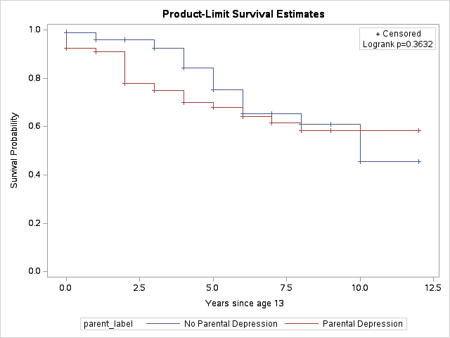

HYPOTHESIS 1b: Cox Regression for Adolescent/Early Adulthood Depression Onset (>=13 years)

Effect of Parental Depression controlling for demographics and social characteristics

The PHREG Procedure

| Model Information |  |  |
| --- | --- | --- |
| Data Set | WORK.ADOLESCENT_DATA |  |
| Dependent Variable | entry_time | Entry time (age 13) |
| Dependent Variable | exit_time | Exit time (age at event or censoring) |
| Censoring Variable | event | Event indicator (1=depression, 0=censored) |
| Censoring Value(s) | 0 |  |
| Ties Handling | BRESLOW |  |

| Number of Observations Read Number of Observations Used | 154 136 |
| --- | --- |

| Class Level Information Class | Class Level Information Value | Class Level Information Design Variables |
| --- | --- | --- |
| depress_parent | 0 | 0 |
|  | 1 | 1 |
| gender | 1 | 0 |
|  | 2 | 1 |
| marital_status | 1 | 0 |
|  | 2 | 1 |

| Summary of the Number of Event and Censored Values Total | Summary of the Number of Event and Censored Values Event | Summary of the Number of Event and Censored Values Censored | Summary of the Number of Event and Censored Values Percent Censored |
| --- | --- | --- | --- |
| 136 | 38 | 98 | 72.06 |

| Convergence Status |
| --- |
| Convergence criterion (GCONV=1E-8) satisfied. |

| Model Fit Statistics Criterion | Model Fit Statistics Without Covariates | Model Fit Statistics With Covariates |
| --- | --- | --- |
| -2 LOG L | 334.913 | 327.587 |
| AIC | 334.913 | 337.587 |
| SBC | 334.913 | 345.775 |

| Testing Global Null Hypothesis: BETA=0 Test | Testing Global Null Hypothesis: BETA=0 Chi-Square | Testing Global Null Hypothesis: BETA=0 DF | Testing Global Null Hypothesis: BETA=0 Pr > ChiSq |
| --- | --- | --- | --- |
| Likelihood Ratio | 7.3257 | 5 | 0.1975 |
| Score | 7.2256 | 5 | 0.2044 |
| Wald | 7.0132 | 5 | 0.2197 |

| Type 3 Tests Effect | Type 3 Tests DF | Type 3 Tests Wald Chi-Square | Type 3 Tests Pr > ChiSq |
| --- | --- | --- | --- |
| depress_parent | 1 | 0.0796 | 0.7779 |
| gender | 1 | 5.2800 | 0.0216 |
| age | 1 | 0.0859 | 0.7695 |
| social_class | 1 | 0.6392 | 0.4240 |
| marital_status | 1 | 2.0802 | 0.1492 |

| Analysis of Maximum Likelihood Estimates Parameter | Analysis of Maximum Likelihood Estimates | Analysis of Maximum Likelihood Estimates DF | Analysis of Maximum Likelihood Estimates Parameter Estimate | Analysis of Maximum Likelihood Estimates Standard Error | Analysis of Maximum Likelihood Estimates Chi-Square | Analysis of Maximum Likelihood Estimates Pr > ChiSq | Analysis of Maximum Likelihood Estimates Hazard Ratio | Analysis of Maximum Likelihood Estimates 95% Hazard Ratio Confidence Limits | Analysis of Maximum Likelihood Estimates 95% Hazard Ratio Confidence Limits | Analysis of Maximum Likelihood Estimates Label |
| --- | --- | --- | --- | --- | --- | --- | --- | --- | --- | --- |
| depress_parent | 1 | 1 | 0.09540 | 0.33816 | 0.0796 | 0.7779 | 1.100 | 0.567 | 2.134 | Parental Depression (0=No, 1=Yes) 1 |
| gender | 2 | 1 | 0.80008 | 0.34819 | 5.2800 | 0.0216 | 2.226 | 1.125 | 4.404 | Gender (1=Male, 2=Female) 2 |
| age |  | 1 | -0.02166 | 0.07394 | 0.0859 | 0.7695 | 0.979 | 0.847 | 1.131 | Age at Interview |
| social_class |  | 1 | 0.13001 | 0.16261 | 0.6392 | 0.4240 | 1.139 | 0.828 | 1.566 | Social Class (1=Highest, 5=Lowest) |
| marital_status | 2 | 1 | 0.54098 | 0.37508 | 2.0802 | 0.1492 | 1.718 | 0.824 | 3.583 | Marital Status (1=Married, 2=Sep/Div) 2 |

HYPOTHESIS 1b: Cox Regression with PH Assumption Test

The PHREG Procedure

| Model Information |  |  |
| --- | --- | --- |
| Data Set | WORK.ADOLESCENT_DATA |  |
| Dependent Variable | entry_time | Entry time (age 13) |
| Dependent Variable | exit_time | Exit time (age at event or censoring) |
| Censoring Variable | event | Event indicator (1=depression, 0=censored) |
| Censoring Value(s) | 0 |  |
| Ties Handling | EFRON |  |

| Number of Observations Read Number of Observations Used | 154 136 |
| --- | --- |

| Class Level Information Class | Class Level Information Value | Class Level Information Design Variables |
| --- | --- | --- |
| depress_parent | 0 | 0 |
|  | 1 | 1 |
| gender | 1 | 0 |
|  | 2 | 1 |
| marital_status | 1 | 0 |
|  | 2 | 1 |

| Summary of the Number of Event and Censored Values Total | Summary of the Number of Event and Censored Values Event | Summary of the Number of Event and Censored Values Censored | Summary of the Number of Event and Censored Values Percent Censored |
| --- | --- | --- | --- |
| 136 | 38 | 98 | 72.06 |

| Convergence Status |
| --- |
| Convergence criterion (GCONV=1E-8) satisfied. |

| Model Fit Statistics Criterion | Model Fit Statistics Without Covariates | Model Fit Statistics With Covariates |
| --- | --- | --- |
| -2 LOG L | 332.835 | 325.040 |
| AIC | 332.835 | 335.040 |
| SBC | 332.835 | 343.228 |

| Testing Global Null Hypothesis: BETA=0 Test | Testing Global Null Hypothesis: BETA=0 Chi-Square | Testing Global Null Hypothesis: BETA=0 DF | Testing Global Null Hypothesis: BETA=0 Pr > ChiSq |
| --- | --- | --- | --- |
| Likelihood Ratio | 7.7950 | 5 | 0.1679 |
| Score | 7.6730 | 5 | 0.1752 |
| Wald | 7.4337 | 5 | 0.1903 |

| Type 3 Tests Effect | Type 3 Tests DF | Type 3 Tests Wald Chi-Square | Type 3 Tests Pr > ChiSq |
| --- | --- | --- | --- |
| depress_parent | 1 | 0.0858 | 0.7696 |
| gender | 1 | 5.6247 | 0.0177 |
| age | 1 | 0.0771 | 0.7813 |
| social_class | 1 | 0.6927 | 0.4053 |
| marital_status | 1 | 2.2804 | 0.1310 |

| Analysis of Maximum Likelihood Estimates Parameter | Analysis of Maximum Likelihood Estimates | Analysis of Maximum Likelihood Estimates DF | Analysis of Maximum Likelihood Estimates Parameter Estimate | Analysis of Maximum Likelihood Estimates Standard Error | Analysis of Maximum Likelihood Estimates Chi-Square | Analysis of Maximum Likelihood Estimates Pr > ChiSq | Analysis of Maximum Likelihood Estimates Hazard Ratio | Analysis of Maximum Likelihood Estimates Label |
| --- | --- | --- | --- | --- | --- | --- | --- | --- |
| depress_parent | 1 | 1 | 0.09890 | 0.33763 | 0.0858 | 0.7696 | 1.104 | Parental Depression (0=No, 1=Yes) 1 |
| gender | 2 | 1 | 0.82807 | 0.34915 | 5.6247 | 0.0177 | 2.289 | Gender (1=Male, 2=Female) 2 |
| age |  | 1 | -0.02048 | 0.07375 | 0.0771 | 0.7813 | 0.980 | Age at Interview |
| social_class |  | 1 | 0.13566 | 0.16300 | 0.6927 | 0.4053 | 1.145 | Social Class (1=Highest, 5=Lowest) |
| marital_status | 2 | 1 | 0.56704 | 0.37550 | 2.2804 | 0.1310 | 1.763 | Marital Status (1=Married, 2=Sep/Div) 2 |

HYPOTHESIS 1b: Cox Model with Age*Time Interaction

Addresses PH violation for age covariate (p=0.021)

The PHREG Procedure

| Model Information |  |  |
| --- | --- | --- |
| Data Set | WORK.ADOLESCENT_DATA |  |
| Dependent Variable | entry_time | Entry time (age 13) |
| Dependent Variable | exit_time | Exit time (age at event or censoring) |
| Censoring Variable | event | Event indicator (1=depression, 0=censored) |
| Censoring Value(s) | 0 |  |
| Ties Handling | BRESLOW |  |

| Number of Observations Read Number of Observations Used | 154 136 |
| --- | --- |

| Class Level Information Class | Class Level Information Value | Class Level Information Design Variables |
| --- | --- | --- |
| depress_parent | 0 | 0 |
|  | 1 | 1 |
| gender | 1 | 0 |
|  | 2 | 1 |
| marital_status | 1 | 0 |
|  | 2 | 1 |

| Summary of the Number of Event and Censored Values Total | Summary of the Number of Event and Censored Values Event | Summary of the Number of Event and Censored Values Censored | Summary of the Number of Event and Censored Values Percent Censored |
| --- | --- | --- | --- |
| 136 | 38 | 98 | 72.06 |

| Convergence Status |
| --- |
| Convergence criterion (GCONV=1E-8) satisfied. |

| Model Fit Statistics Criterion | Model Fit Statistics Without Covariates | Model Fit Statistics With Covariates |
| --- | --- | --- |
| -2 LOG L | 334.913 | 326.314 |
| AIC | 334.913 | 338.314 |
| SBC | 334.913 | 348.139 |

| Testing Global Null Hypothesis: BETA=0 Test | Testing Global Null Hypothesis: BETA=0 Chi-Square | Testing Global Null Hypothesis: BETA=0 DF | Testing Global Null Hypothesis: BETA=0 Pr > ChiSq |
| --- | --- | --- | --- |
| Likelihood Ratio | 8.5991 | 6 | 0.1974 |
| Score | 8.4000 | 6 | 0.2102 |
| Wald | 8.1076 | 6 | 0.2303 |

| Type 3 Tests Effect | Type 3 Tests DF | Type 3 Tests Wald Chi-Square | Type 3 Tests Pr > ChiSq |
| --- | --- | --- | --- |
| depress_parent | 1 | 0.1032 | 0.7480 |
| gender | 1 | 5.2802 | 0.0216 |
| age | 1 | 1.3083 | 0.2527 |
| social_class | 1 | 0.7644 | 0.3820 |
| marital_status | 1 | 1.8840 | 0.1699 |
| age_time | 1 | 1.2864 | 0.2567 |

| Analysis of Maximum Likelihood Estimates Parameter | Analysis of Maximum Likelihood Estimates | Analysis of Maximum Likelihood Estimates DF | Analysis of Maximum Likelihood Estimates Parameter Estimate | Analysis of Maximum Likelihood Estimates Standard Error | Analysis of Maximum Likelihood Estimates Chi-Square | Analysis of Maximum Likelihood Estimates Pr > ChiSq | Analysis of Maximum Likelihood Estimates Hazard Ratio | Analysis of Maximum Likelihood Estimates Label |
| --- | --- | --- | --- | --- | --- | --- | --- | --- |
| depress_parent | 1 | 1 | 0.10876 | 0.33857 | 0.1032 | 0.7480 | 1.115 | Parental Depression (0=No, 1=Yes) 1 |
| gender | 2 | 1 | 0.80351 | 0.34967 | 5.2802 | 0.0216 | 2.233 | Gender (1=Male, 2=Female) 2 |
| age |  | 1 | -2.20526 | 1.92801 | 1.3083 | 0.2527 | 0.110 | Age at Interview |
| social_class |  | 1 | 0.14326 | 0.16387 | 0.7644 | 0.3820 | 1.154 | Social Class (1=Highest, 5=Lowest) |
| marital_status | 2 | 1 | 0.51747 | 0.37701 | 1.8840 | 0.1699 | 1.678 | Marital Status (1=Married, 2=Sep/Div) 2 |
| age_time |  | 1 | 0.78557 | 0.69262 | 1.2864 | 0.2567 | 2.194 |  |

Substance Abuse Analysis: Key Variables

The FREQ Procedure

| Censoring Status for Substance Abuse (1=Censored, 0=Event) censor_subst | Censoring Status for Substance Abuse (1=Censored, 0=Event) Frequency | Censoring Status for Substance Abuse (1=Censored, 0=Event) Cumulative Frequency |
| --- | --- | --- |
| 0 | 28 | 28 |
| 1 | 192 | 220 |

| Frequency |
| --- |

| Table of prior_depression by depress_parent prior_depression(Prior Depression Before Substance Abuse (1=Yes, 0=No)) | Table of prior_depression by depress_parent depress_parent(Parental Depression (0=No, 1=Yes)) 0 | Table of prior_depression by depress_parent depress_parent(Parental Depression (0=No, 1=Yes)) 1 | Table of prior_depression by depress_parent depress_parent(Parental Depression (0=No, 1=Yes)) Total |
| --- | --- | --- | --- |
| 0 | 76 | 83 | 159 |
| 1 | 19 | 42 | 61 |
| Total | 95 | 125 | 220 |

Substance Abuse Onset Age Distribution (Events Only)

The MEANS Procedure

| Analysis Variable : time_subst Time to Substance Abuse Onset or Censoring N | Analysis Variable : time_subst Time to Substance Abuse Onset or Censoring Minimum | Analysis Variable : time_subst Time to Substance Abuse Onset or Censoring Maximum | Analysis Variable : time_subst Time to Substance Abuse Onset or Censoring Mean | Analysis Variable : time_subst Time to Substance Abuse Onset or Censoring Median |
| --- | --- | --- | --- | --- |
| 28 | 12.0000000 | 25.0000000 | 17.4642857 | 16.5000000 |

Substance Abuse Onset Age Frequencies (Events Only)

The FREQ Procedure

| Time to Substance Abuse Onset or Censoring time_subst | Time to Substance Abuse Onset or Censoring Frequency | Time to Substance Abuse Onset or Censoring Percent | Time to Substance Abuse Onset or Censoring Cumulative Frequency | Time to Substance Abuse Onset or Censoring Cumulative Percent |
| --- | --- | --- | --- | --- |
| 12 | 3 | 10.71 | 3 | 10.71 |
| 13 | 1 | 3.57 | 4 | 14.29 |
| 14 | 3 | 10.71 | 7 | 25.00 |
| 15 | 3 | 10.71 | 10 | 35.71 |
| 16 | 4 | 14.29 | 14 | 50.00 |
| 17 | 1 | 3.57 | 15 | 53.57 |
| 18 | 2 | 7.14 | 17 | 60.71 |
| 19 | 2 | 7.14 | 19 | 67.86 |
| 20 | 2 | 7.14 | 21 | 75.00 |
| 21 | 2 | 7.14 | 23 | 82.14 |
| 22 | 2 | 7.14 | 25 | 89.29 |
| 23 | 1 | 3.57 | 26 | 92.86 |
| 24 | 1 | 3.57 | 27 | 96.43 |
| 25 | 1 | 3.57 | 28 | 100.00 |

HYPOTHESIS 2a: Survival Curves for Substance Abuse Onset

Stratified by Prior Depression in Offspring

The LIFETEST Procedure

Stratum 1: Prior Depression Before Substance Abuse (1=Yes, 0=No) = 0

| Product-Limit Survival Estimates time_subst | Product-Limit Survival Estimates | Product-Limit Survival Estimates Survival | Product-Limit Survival Estimates Failure | Product-Limit Survival Estimates Survival Standard Error | Product-Limit Survival Estimates Number Failed | Product-Limit Survival Estimates Number Left |
| --- | --- | --- | --- | --- | --- | --- |
| 0.0000 |  | 1.0000 | 0 | 0 | 0 | 159 |
| 5.0000 | * | . | . | . | 0 | 158 |
| 6.0000 | * | . | . | . | 0 | 157 |
| 6.0000 | * | . | . | . | 0 | 156 |
| 7.0000 | * | . | . | . | 0 | 155 |
| 7.0000 | * | . | . | . | 0 | 154 |
| 7.0000 | * | . | . | . | 0 | 153 |
| 7.0000 | * | . | . | . | 0 | 152 |
| 7.0000 | * | . | . | . | 0 | 151 |
| 8.0000 | * | . | . | . | 0 | 150 |
| 8.0000 | * | . | . | . | 0 | 149 |
| 8.0000 | * | . | . | . | 0 | 148 |
| 8.0000 | * | . | . | . | 0 | 147 |
| 8.0000 | * | . | . | . | 0 | 146 |
| 9.0000 | * | . | . | . | 0 | 145 |
| 9.0000 | * | . | . | . | 0 | 144 |
| 9.0000 | * | . | . | . | 0 | 143 |
| 9.0000 | * | . | . | . | 0 | 142 |
| 9.0000 | * | . | . | . | 0 | 141 |
| 9.0000 | * | . | . | . | 0 | 140 |
| 9.0000 | * | . | . | . | 0 | 139 |
| 10.0000 | * | . | . | . | 0 | 138 |
| 10.0000 | * | . | . | . | 0 | 137 |
| 10.0000 | * | . | . | . | 0 | 136 |
| 10.0000 | * | . | . | . | 0 | 135 |
| 10.0000 | * | . | . | . | 0 | 134 |
| 11.0000 | * | . | . | . | 0 | 133 |
| 11.0000 | * | . | . | . | 0 | 132 |
| 11.0000 | * | . | . | . | 0 | 131 |
| 11.0000 | * | . | . | . | 0 | 130 |

[output cut: 130 more lines]

Note:The marked survival times are censored observations.

Summary Statistics for Time Variable time_subst

| Quartile Estimates Percent | Quartile Estimates Point Estimate | Quartile Estimates 95% Confidence Interval Transform | Quartile Estimates 95% Confidence Interval [Lower | Quartile Estimates 95% Confidence Interval Upper) |
| --- | --- | --- | --- | --- |
| 75 | . | LOGLOG | . | . |
| 50 | . | LOGLOG | . | . |
| 25 | 22.0000 | LOGLOG | 19.0000 | . |

| Mean | Standard Error |
| --- | --- |
| 20.8774 | 0.2623 |

Note:The mean survival time and its standard error were underestimated because the largest observation was censored and the estimation was restricted to the largest event time.

HYPOTHESIS 2a: Survival Curves for Substance Abuse Onset

Stratified by Prior Depression in Offspring

The LIFETEST Procedure